# House Prices India Notebook

#LIBRARIES

```r
library("readr")
library("scales")
library("dplyr")
library("corrplot")
library("vioplot")
library("tidyr")
library("factoextra")
library("GGally")
library("dplyr")
#library("ggplot")
library("qwraps2")
library("lubridate")
library("dbscan")
library("ggplot2")
library("gdtools")
library("Cairo")
library("stringr")
library("data.table")
library("modelr")
library("DataExplorer")
library("corrplot")
library("plotly")
library("nortest")
library("ggrepel")
library("raster")
library("sp")
library("rgeos")
#library("spTransform")
library("dplyr")
library("caret")
library("rpart")
library("ggmap")
library("tidyr")
library("vioplot")
```

Column Description POSTED_BY Category marking who has listed the property UNDER_CONSTRUCTION Under Construction or Not RERA Rera approved or Not. Note: RERA stands for Real Estate Regulatory Authority. It is a regulatory body established in many countries to oversee and regulate the real estate sector BHK_NO Number of Rooms BHK_OR_RK Type of property. Note: BHK: BHK stands for Bedroom, Hall, and Kitchen; K stands for Room Kitchen. It is used to describe smaller residential unit SQUARE_FT Total area of the house in square feet READY_TO_MOVE Category marking Ready to move or Not RESALE Category marking Resale or not ADDRESS Address of the property LONGITUDE Longitude of the property  
LATITUDE Latitude of the property  
price_LACs Target price of the property

#READ FILE / DATAFRAME

```r
setwd("C:/Users/manue/Downloads/House Price Prediction Challenge/dataset")
house_prices = read_csv('./train.csv')
dim(house_prices)    #12 features
```

```
[1] 29451    12
```

```r
str(house_prices)
```

```
spc_tbl_ [29,451 × 12] (S3: spec_tbl_df/tbl_df/tbl/data.frame)
 $ POSTED_BY            : chr [1:29451] "Owner" "Dealer" "Owner" "Owner" ...
 $ UNDER_CONSTRUCTION   : num [1:29451] 0 0 0 0 1 0 0 0 0 0 ...
 $ RERA                 : num [1:29451] 0 0 0 1 0 0 0 1 1 1 ...
 $ BHK_NO.              : num [1:29451] 2 2 2 2 2 3 3 3 2 2 ...
 $ BHK_OR_RK            : chr [1:29451] "BHK" "BHK" "BHK" "BHK" ...
 $ SQUARE_FT            : num [1:29451] 1300 1275 933 930 999 ...
 $ READY_TO_MOVE        : num [1:29451] 1 1 1 1 0 1 1 1 1 1 ...
 $ RESALE               : num [1:29451] 1 1 1 1 1 1 1 1 1 1 ...
 $ ADDRESS              : chr [1:29451] "Ksfc Layout,Bangalore" "Vishweshwara Nagar,Mysore" "Jigani,Bangalore" "Sector-1 Vaishali,Ghaziabad" ...
 $ LONGITUDE            : num [1:29451] 13 12.3 12.8 28.6 22.6 ...
 $ LATITUDE             : num [1:29451] 77.6 76.6 77.6 77.3 88.5 ...
 $ TARGET(PRICE_IN_LACS): num [1:29451] 55 51 43 62.5 60.5 42 66.5 52 41.6 36 ...
 - attr(*, "spec")=
  .. cols(
  ..   POSTED_BY = col_character(),
  ..   UNDER_CONSTRUCTION = col_double(),
  ..   RERA = col_double(),
  ..   BHK_NO. = col_double(),
  ..   BHK_OR_RK = col_character(),
  ..   SQUARE_FT = col_double(),
  ..   READY_TO_MOVE = col_double(),
  ..   RESALE = col_double(),
  ..   ADDRESS = col_character(),
  ..   LONGITUDE = col_double(),
  ..   LATITUDE = col_double(),
  ..   `TARGET(PRICE_IN_LACS)` = col_double()
  .. )
 - attr(*, "problems")=<externalptr>
```

```r
summary(house_prices)
```

```
  POSTED_BY         UNDER_CONSTRUCTION      RERA           BHK_NO.        BHK_OR_RK
 Length:29451       Min.   :0.0000     Min.   :0.0000   Min.   : 1.000   Length:29451
 Class :character   1st Qu.:0.0000     1st Qu.:0.0000   1st Qu.: 2.000   Class :character
 Mode  :character   Median :0.0000     Median :0.0000   Median : 2.000   Mode  :character
                    Mean   :0.1798     Mean   :0.3179   Mean   : 2.392
                    3rd Qu.:0.0000     3rd Qu.:1.0000   3rd Qu.: 3.000
                    Max.   :1.0000     Max.   :1.0000   Max.   :20.000
   SQUARE_FT         READY_TO_MOVE        RESALE         ADDRESS            LONGITUDE
 Min.   :        3   Min.   :0.0000   Min.   :0.0000   Length:29451       Min.   :-37.71
 1st Qu.:      900   1st Qu.:1.0000   1st Qu.:1.0000   Class :character   1st Qu.: 18.45
 Median :     1175   Median :1.0000   Median :1.0000   Mode  :character   Median : 20.75
 Mean   :    19802   Mean   :0.8202   Mean   :0.9296                      Mean   : 21.30
 3rd Qu.:     1551   3rd Qu.:1.0000   3rd Qu.:1.0000                      3rd Qu.: 26.90
 Max.   :254545454   Max.   :1.0000   Max.   :1.0000                      Max.   : 59.91
    LATITUDE       TARGET(PRICE_IN_LACS)
 Min.   :-121.76   Min.   :    0.25
 1st Qu.:  73.80   1st Qu.:   38.00
 Median :  77.32   Median :   62.00
 Mean   :  76.84   Mean   :  142.90
 3rd Qu.:  77.83   3rd Qu.:  100.00
 Max.   : 152.96   Max.   :30000.00
```

#Missing values?

```r
sum(is.na(house_prices))
```

```
[1] 0
```

# BINARY FEATURES

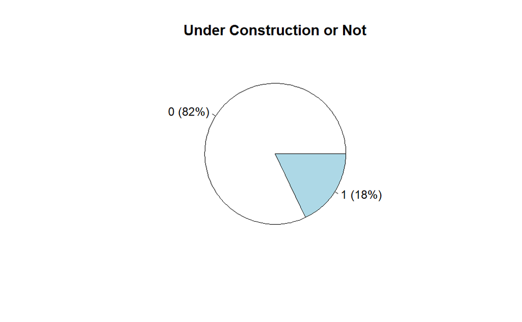

```r
proportions <- prop.table(table(house_prices$UNDER_CONSTRUCTION))
proportions <- as.numeric(proportions)
labels <- paste0(c("0", "1"), " (", scales::percent(proportions), ")")
pie(proportions, labels = labels, main = "Under Construction or Not")
```

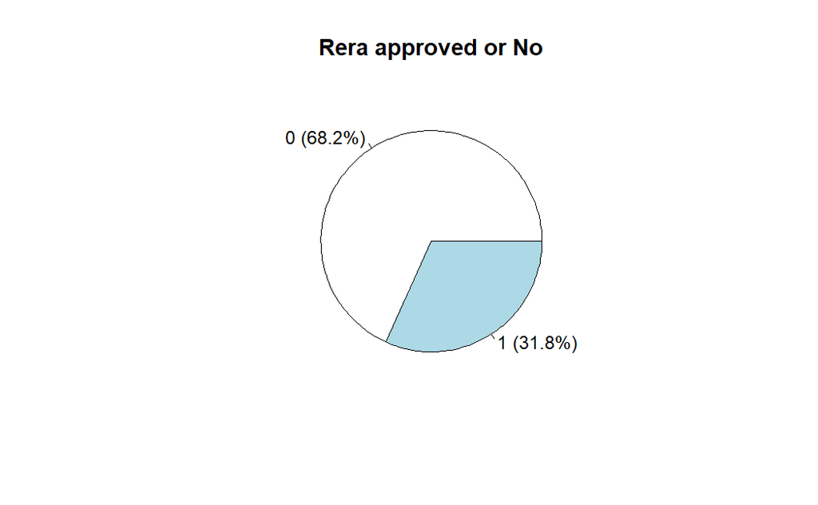

```r
proportions <- prop.table(table(house_prices$RERA))
proportions <- as.numeric(proportions)
labels <- paste0(c("0", "1"), " (", sprintf("%.1f%%", proportions*100), ")")
pie(proportions, labels = labels, main = "Rera approved or No")
```

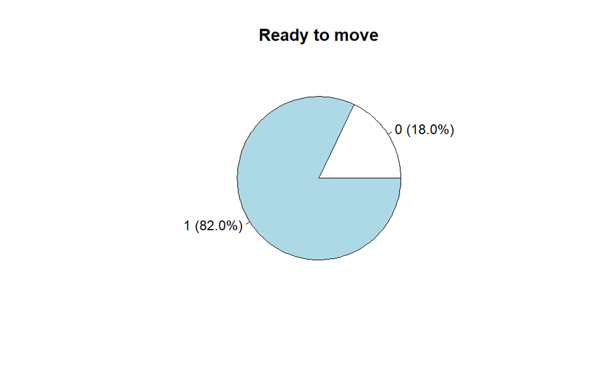

```r
proportions <- prop.table(table(house_prices$READY_TO_MOVE))
proportions <- as.numeric(proportions)
labels <- paste0(c("0", "1"), " (", sprintf("%.1f%%", proportions*100), ")")
pie(proportions, labels = labels, main = "Ready to move")
```

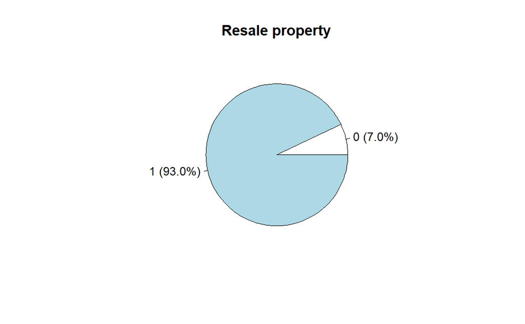

```r
proportions <- prop.table(table(house_prices$RESALE))
proportions <- as.numeric(proportions)
labels <- paste0(c("0", "1"), " (", sprintf("%.1f%%", proportions*100), ")")
pie(proportions, labels = labels, main = "Resale property")
```